# IntClust Classification Reveals Hidden Prognostic Heterogeneity in PAM50 Luminal Breast Cancer: Implications for Patient Communication

Hanna Hong

2026-02-27

# Abstract

**Background:** PAM50 classification stratifies breast cancer patients into molecular subtypes with distinct prognoses and guides patient communication about expected outcomes. However, PAM50 is based solely on gene expression and may not capture prognostic heterogeneity driven by copy number alterations. The IntClust classification system integrates copy number data with expression profiles, potentially revealing risk differences hidden within PAM50 categories.

**Methods:** We analysed 1,974 METABRIC patients with complete PAM50, IntClust, and survival data. Gene expression analysis focused on therapeutically relevant genes (ESR1, CCND1, FGFR1) using PCA and Wilcoxon rank-sum tests. Mutation profiling was performed with maftools, examining TP53 and PIK3CA patterns across IntClust groups using chi-square tests. Kaplan-Meier survival analysis with log-rank tests assessed whether IntClust classification stratifies patients beyond PAM50 and clinical variables, with extension analysis quantifying hidden heterogeneity within PAM50 Luminal patients.

**Results:** Among 1,175 PAM50 Luminal patients, approximately one in five (18.6%) belonged to hidden high-risk IntClust groups (2, 6, 9) showing 10 percentage point higher mortality (67.1% vs 57.1%) and approximately 23-month worse median survival (p < 0.001). Gene expression analysis confirmed CCND1 and FGFR1 elevation in high-risk groups (both p < 2e-16) despite uniform ESR1 expression (p = 0.15). Mutation analysis revealed distinct patterns: TP53 mutations were enriched in high-risk groups while PIK3CA mutations predominated in low-risk groups. Standard clinical variables (age, ER status, menopausal status) could not identify the hidden high-risk subset.

**Conclusion:** Nearly one in five PAM50 Luminal patients harbour high-risk genomic features, including CCND1 and FGFR1 amplifications with therapeutic implications, not conveyed in current patient communication, supporting the need for comprehensive genomic profiling to inform personalised prognostic discussions.

# 1. Introduction

Breast cancer is the most common cancer in women globally, with over 2 million new cases diagnosed annually (Sung et al. 2021). It comprises multiple molecular subtypes with distinct biology and prognosis. Early molecular classification efforts identified intrinsic subtypes based on gene expression patterns (Perou et al. 2000; Sørlie et al. 2001), which were later refined into the clinical PAM50 assay (Parker et al. 2009). This classification guides treatment decisions and patient counselling about prognosis.

However, PAM50 uses only gene expression data and doesn’t capture structural genomic changes like amplifications and deletions. While PAM50 has demonstrated clinical utility and is incorporated into genomic tests like Prosigna (Cardoso et al. 2016), the METABRIC study integrated copy number alterations with expression profiles, identifying 10 “integrative clusters” (IntClust 1-10) with distinct genomic drivers (Curtis et al. 2012). Importantly, IntClust groups don’t align perfectly with PAM50 subtypes, some tumours classified as “Luminal” by PAM50 belong to high-risk IntClust groups.

Current patient communication relies heavily on PAM50 classification. Patients with “Luminal” breast cancer typically hear they have a favourable prognosis and will receive endocrine therapy. However, if IntClust reveals substantial heterogeneity within PAM50 Luminal disease, then some patients may be receiving incomplete prognostic information. This study quantifies this potential communication gap using the METABRIC dataset.

This report examines whether IntClust classification reveals clinically meaningful heterogeneity within PAM50 Luminal breast cancer, focusing on three analytical questions. We first characterise gene expression patterns of therapeutically relevant genes (ESR1, CCND1, FGFR1) across IntClust groups. We then identify mutation profiles, particularly TP53 and PIK3CA, and assess how they differ across subtypes. Finally, we evaluate whether IntClust stratifies patients beyond PAM50 and standard clinical variables through survival analysis. As an extension, we quantify the proportion of PAM50 Luminal patients with hidden high-risk profiles and consider implications for how risk is communicated to patients.

# 2. Methods

## 2.1 Data Sources

Clinical and mutation data from the METABRIC study (Curtis et al. 2012) were obtained from cBioPortal (https://www.cbioportal.org). Gene expression data were accessed from the repository on Zenodo (https://doi.org/10.5281/zenodo.18587856). All data are publicly available and de-identified, with no individual patient identifiers retained. The original METABRIC study obtained ethical approval from institutional review boards at participating centres in the UK and Canada, as described in Curtis et al. (2012). cBioPortal provides open access to de-identified cancer genomics datasets under standard academic use terms. As this analysis uses only publicly available, fully anonymised secondary data with no possibility of re-identification, no additional ethical approval was required for this study. All analyses comply with the principles of data minimisation and purpose limitation consistent with UK data protection requirements.

## 2.2 Data Preprocessing

The original cohort comprised 2509 patients. We excluded patients missing PAM50 classification, IntClust classification, or survival data, resulting in 1974 patients for analysis (535 excluded).

For mutation analysis, we restricted to patients with available mutation data (n = 1860).

## 2.3 Statistical Analyses

### Gene Expression Analysis (Question 1)

We chose IntClust as the subtype definition rather than PAM50 because IntClust integrates copy number alterations with expression data, potentially revealing prognostic heterogeneity hidden within PAM50 categories (Curtis et al. 2012). For gene expression analysis, we focused on three genes selected for their established prognostic and therapeutic significance in breast cancer molecular subtypes: ESR1 (estrogen receptor, defining ER-positive status and guiding hormone therapy), CCND1 (located at 11q13.3, the defining amplicon of IntClust 2; Curtis et al., 2012), and FGFR1 (located at 8p12, the defining amplicon of IntClust 6; Curtis et al., 2012). These genes were selected because they represent the key genomic drivers of the IntClust subtypes under investigation and have emerging therapeutic relevance through CDK4/6 inhibitors (targeting CCND1-driven tumours) and FGFR inhibitors (targeting FGFR1-amplified tumours; Formisano et al., 2019).

Principal component analysis (PCA) was performed using these three genes plus clinically established supporting markers: PGR (progesterone receptor, routinely assessed alongside ESR1), MKI67 (Ki-67, standard proliferation marker distinguishing Luminal A from B; Sørlie et al., 2001), ERBB2 (HER2, defining receptor status), and TP53 (tumour suppressor, frequently mutated in aggressive subtypes). These seven genes collectively capture oestrogen signalling, proliferation, HER2 pathway activity, and genomic instability, the key biological axes differentiating breast cancer subtypes.

Expression differences between IntClust groups were tested using Wilcoxon rank-sum tests, chosen as a non-parametric alternative that does not assume normality in expression distributions. Statistical significance was set at p < 0.05.

### Mutation Analysis (Question 2)

Mutation data were analysed using maftools package (Mayakonda et al. 2018), which provides comprehensive tools for visualizing and analyzing somatic variants in cancer genomes. We calculated:

- Mutation burden (total mutations per sample)
- Gene-level mutation frequencies
- Subtype-specific mutation patterns

Chi-square tests assessed whether mutation frequencies differed across IntClust groups. Oncoplot visualisations displayed the top 20 most frequently mutated genes across samples.

### Survival Analysis (Question 3 & Extension)

Overall survival was analysed using Kaplan-Meier estimation and log-rank tests. Survival curves compared:

- IntClust risk groups (low-risk: 3, 7, 8; high-risk: 2, 6, 9)
- IntClust stratification within ER-positive patients
- IntClust stratification within PAM50 Luminal patients (extension)

P-values < 0.05 were considered statistically significant.

## 2.4 Software

All analyses were performed in R version 4.5.2. Key packages: tidyverse (data manipulation), survival and survminer (survival analysis), maftools (mutation analysis), pheatmap (heatmaps), ggplot2 (visualisation), gtsummary (tables).

## 2.5 Data and Code Availability

Clinical and mutation data are publicly available from [cBioPortal](https://www.cbioportal.org/study/summary?id=brca_metabric). Expression data are archived on [Zenodo](https://doi.org/10.5281/zenodo.18587856). All analysis code is available in this R Markdown document.

# 3. Results

## 3.1 Data Exploration and Cohort Characteristics

The METABRIC dataset is a curated teaching subset of the original Molecular Taxonomy of Breast Cancer International Consortium study, comprising clinical annotations, normalised gene expression data, and somatic mutation data in MAF format. Initial quality checks identified a typographical error in ER status values (“Positve” corrected to “Positive”), 535 patients with missing classification or survival data, and one subtype label “NC” (not classified) requiring exclusion. After these cleaning steps, 1974 patients remained for analysis. Gene expression data were available for 1974 patients, and mutation data for 1860 patients overlapping with the clinical cohort.

**Table 1A: Clinical and Demographic Characteristics by PAM50 Subtype**

| **Characteristic** | **N** | **Overall** N = 1,974<sup>1</sup> | **Basal** N = 209<sup>1</sup> | **claudin-low** N = 218<sup>1</sup> | **Her2** N = 224<sup>1</sup> | **LumA** N = 700<sup>1</sup> | **LumB** N = 475<sup>1</sup> | **Normal** N = 148<sup>1</sup> | **p-value**<sup>2</sup> |
| --- | --- | --- | --- | --- | --- | --- | --- | --- | --- |
| Age at diagnosis, years | 1,974 | 61.8 (51.4, 70.6) | 54.2 (43.5, 65.4) | 58.7 (49.1, 66.6) | 59.1 (50.4, 68.7) | 63.4 (53.1, 72.3) | 66.5 (58.8, 74.0) | 57.1 (46.3, 66.3) | <0.001 |
| Menopausal status | 1,974 |  |  |  |  |  |  |  | <0.001 |
| Post |  | 1,550 (78.5%) | 126 (60.3%) | 158 (72.5%) | 171 (76.3%) | 574 (82.0%) | 425 (89.5%) | 96 (64.9%) |  |
| Pre |  | 424 (21.5%) | 83 (39.7%) | 60 (27.5%) | 53 (23.7%) | 126 (18.0%) | 50 (10.5%) | 52 (35.1%) |  |
| ER status (IHC) | 1,931 |  |  |  |  |  |  |  | <0.001 |
| Negative |  | 439 (22.7%) | 172 (83.9%) | 100 (48.5%) | 115 (52.8%) | 13 (1.9%) | 11 (2.4%) | 28 (19.3%) |  |
| Positive |  | 1,492 (77.3%) | 33 (16.1%) | 106 (51.5%) | 103 (47.2%) | 677 (98.1%) | 456 (97.6%) | 117 (80.7%) |  |
| HER2 status (SNP6) | 1,974 |  |  |  |  |  |  |  | <0.001 |
| GAIN |  | 437 (22.1%) | 34 (16.3%) | 35 (16.1%) | 149 (66.5%) | 77 (11.0%) | 119 (25.1%) | 23 (15.5%) |  |
| LOSS |  | 101 (5.1%) | 13 (6.2%) | 11 (5.0%) | 4 (1.8%) | 36 (5.1%) | 33 (6.9%) | 4 (2.7%) |  |
| NEUTRAL |  | 1,431 (72.5%) | 162 (77.5%) | 172 (78.9%) | 71 (31.7%) | 585 (83.6%) | 321 (67.6%) | 120 (81.1%) |  |
| UNDEF |  | 5 (0.3%) | 0 (0.0%) | 0 (0.0%) | 0 (0.0%) | 2 (0.3%) | 2 (0.4%) | 1 (0.7%) |  |
| Received chemotherapy | 1,974 | 412 (20.9%) | 113 (54.1%) | 73 (33.5%) | 88 (39.3%) | 56 (8.0%) | 47 (9.9%) | 35 (23.6%) | <0.001 |
| Received hormone therapy | 1,974 | 1,212 (61.4%) | 60 (28.7%) | 110 (50.5%) | 97 (43.3%) | 477 (68.1%) | 379 (79.8%) | 89 (60.1%) | <0.001 |
| Received radiotherapy | 1,974 | 1,171 (59.3%) | 141 (67.5%) | 145 (66.5%) | 134 (59.8%) | 378 (54.0%) | 299 (62.9%) | 74 (50.0%) | <0.001 |
| Overall survival, months | 1,974 | 116.3 (60.7, 185.2) | 85.5 (32.8, 182.6) | 116.2 (64.0, 192.3) | 97.1 (39.2, 171.5) | 130.1 (81.7, 196.7) | 104.1 (55.1, 164.3) | 121.1 (63.7, 175.9) | <0.001 |
| Vital status | 1,974 |  |  |  |  |  |  |  | <0.001 |
| 0:LIVING |  | 836 (42.4%) | 94 (45.0%) | 124 (56.9%) | 67 (29.9%) | 322 (46.0%) | 160 (33.7%) | 69 (46.6%) |  |
| 1:DECEASED |  | 1,138 (57.6%) | 115 (55.0%) | 94 (43.1%) | 157 (70.1%) | 378 (54.0%) | 315 (66.3%) | 79 (53.4%) |  |

<sup>1</sup> Median (IQR) for continuous variables; n (%) for categorical variables  
<sup>2</sup> Kruskal-Wallis rank sum test; Pearson’s Chi-squared test

**Table 1B: Distribution of IntClust Groups Within PAM50 Subtypes**

| <sup>1</sup> | **IntClust Group** 1<sup>1</sup> | **IntClust Group** 10<sup>1</sup> | **IntClust Group** 2<sup>1</sup> | **IntClust Group** 3<sup>1</sup> | **IntClust Group** 4ER-<sup>1</sup> | **IntClust Group** 4ER+<sup>1</sup> | **IntClust Group** 5<sup>1</sup> | **IntClust Group** 6<sup>1</sup> | **IntClust Group** 7<sup>1</sup> | **IntClust Group** 8<sup>1</sup> | **IntClust Group** 9<sup>1</sup> |
| --- | --- | --- | --- | --- | --- | --- | --- | --- | --- | --- | --- |
| PAM50 Subtype |  |  |  |  |  |  |  |  |  |  |  |
| Basal | 8 (3.8%) | 143 (68%) | 1 (0.5%) | 2 (1.0%) | 10 (4.8%) | 7 (3.3%) | 16 (7.7%) | 2 (1.0%) | 3 (1.4%) | 1 (0.5%) | 16 (7.7%) |
| claudin-low | 4 (1.8%) | 60 (28%) | 3 (1.4%) | 13 (6.0%) | 40 (18%) | 80 (37%) | 9 (4.1%) | 2 (0.9%) | 3 (1.4%) | 0 (0%) | 4 (1.8%) |
| Her2 | 19 (8.5%) | 7 (3.1%) | 5 (2.2%) | 8 (3.6%) | 19 (8.5%) | 7 (3.1%) | 105 (47%) | 10 (4.5%) | 9 (4.0%) | 9 (4.0%) | 26 (12%) |
| LumA | 11 (1.6%) | 1 (0.1%) | 25 (3.6%) | 192 (27%) | 1 (0.1%) | 93 (13%) | 17 (2.4%) | 23 (3.3%) | 121 (17%) | 192 (27%) | 24 (3.4%) |
| LumB | 89 (19%) | 14 (2.9%) | 35 (7.4%) | 38 (8.0%) | 0 (0%) | 25 (5.3%) | 33 (6.9%) | 42 (8.8%) | 40 (8.4%) | 89 (19%) | 70 (15%) |
| Normal | 8 (5.4%) | 1 (0.7%) | 3 (2.0%) | 34 (23%) | 13 (8.8%) | 47 (32%) | 10 (6.8%) | 6 (4.1%) | 13 (8.8%) | 8 (5.4%) | 5 (3.4%) |
| Total | 139 (7.0%) | 226 (11%) | 72 (3.6%) | 287 (15%) | 83 (4.2%) | 259 (13%) | 190 (9.6%) | 85 (4.3%) | 189 (9.6%) | 299 (15%) | 145 (7.3%) |

<sup>1</sup> Values are n (row %). Row percentages show distribution of IntClust groups within each PAM50 subtype.

Table 1A summarises clinical and demographic characteristics stratified by PAM50 subtype. The analytical cohort had a median age of 62 years, with 77.3% ER-positive tumours (among those with available ER data). Treatment patterns varied by subtype, with chemotherapy more common in Basal-like compared to Luminal A subtypes (p < 0.001), as expected given the more aggressive biology of Basal-like disease.

Table 1B shows the distribution of IntClust groups within PAM50 subtypes. What stands out here is that IntClust groups 2, 3, 6, 7, 8, and 9 are all predominantly classified as Luminal by PAM50, yet as we show in later sections, they have very different survival outcomes. This cross-tabulation provides the first indication that PAM50 Luminal classification masks substantial molecular and prognostic diversity.

## 3.2 Question 1: Gene Expression Analysis

### Rationale for Gene Selection

We focused on three genes with established prognostic and therapeutic significance that highlight gaps in PAM50-based classification:

**ESR1 (Estrogen Receptor):** Defines ER-positive status, the primary biomarker communicated to patients. High ESR1 expression guides hormone therapy decisions.

**CCND1 (Cyclin D1):** Defines IntClust 2 through 11q13 amplification. The original METABRIC study identified IntClust 2 as a high-risk subgroup (HR = 3.62, 95% CI: 1.91–6.88) compared to other Luminal groups (Curtis et al. 2012). CDK4/6 inhibitors targeting CCND1-driven proliferation are FDA-approved for ER-positive breast cancer (Turner et al. 2015; Finn et al. 2016).

**FGFR1 (Fibroblast Growth Factor Receptor 1):** Defines IntClust 6 through 8p12 amplification. While classified as intermediate prognosis in the original study, IntClust 6 has worse outcomes than the favourable-outcome groups (IntClust 3, 7, 8) (Curtis et al. 2012).

We classified IntClust 2 and 6 as “high-risk” and IntClust 3, 7, and 8 as “low-risk” based on both the original METABRIC survival data and their distinct genomic drivers. IntClust 9 is additionally included as high-risk in the survival analysis (Section 3.4) due to its poor prognosis, though it lacks a single defining amplicon.

### Principal Component Analysis

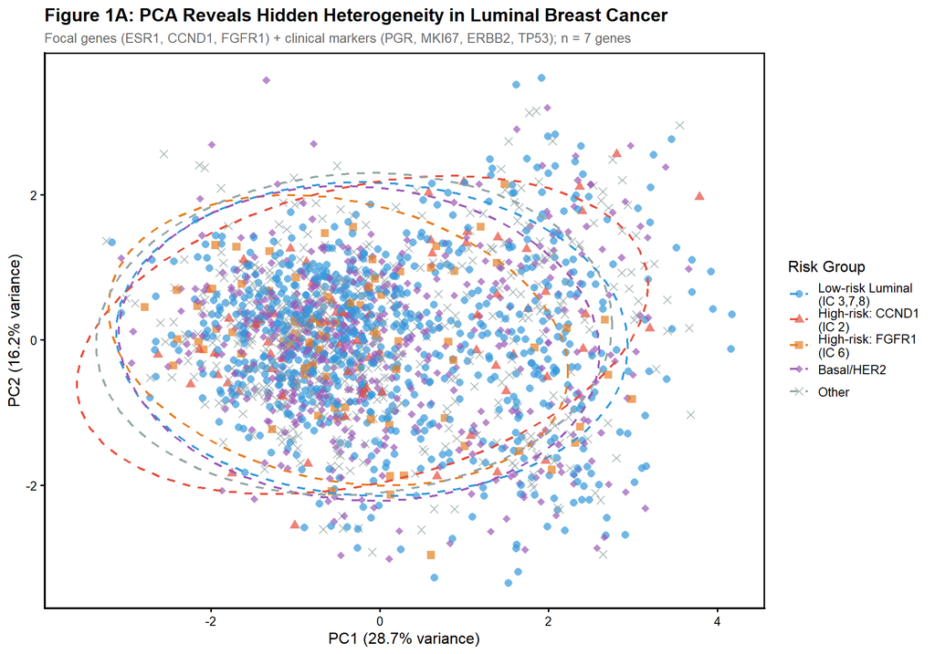

Principal component analysis was performed using the three focal genes plus clinically established markers that capture key biological axes of breast cancer classification: PGR (progesterone receptor, assessed alongside ESR1 clinically), MKI67 (Ki-67 proliferation marker distinguishing Luminal A from B), ERBB2 (HER2 receptor status), and TP53 (tumour suppressor frequently mutated in aggressive subtypes). Together, these 7 genes explained 44.9% of variance (PC1: 28.7%, PC2: 16.2%) (Figure 1A). While substantial overlap exists between IntClust groups, the high-risk Luminal subgroups (IntClust 2 with CCND1, IntClust 6 with FGFR1) occupy partly distinct regions compared to low-risk groups. The modest separation is expected, IntClust integrates copy number alterations which may exert effects beyond simple expression changes. It is worth noting that this PCA uses a targeted set of therapeutically relevant genes rather than the full transcriptome, so it serves as a visualisation of known expression differences rather than an unbiased discovery tool.

### Expression Heatmap

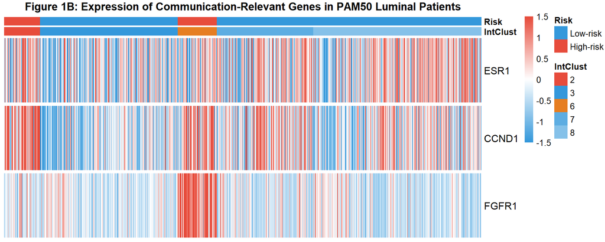

The heatmap displays expression of three therapeutically relevant genes across 797 PAM50 Luminal patients with available expression data (Figure 1B). All samples shown received a “Luminal breast cancer” diagnosis, yet the molecular patterns differ substantially. ESR1 is consistently elevated across all groups, confirming shared ER-positivity. However, CCND1 is specifically elevated in IntClust 2 (reflecting 11q13 amplification) and FGFR1 in IntClust 6 (reflecting 8p12 amplification), these are the two hidden high-risk groups within PAM50 Luminal disease.

### Statistical Comparison

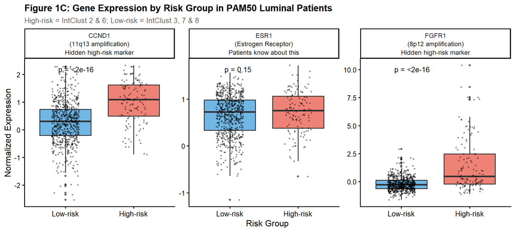

Statistical analysis confirmed distinct expression patterns between risk groups (Figure 1C). ESR1 showed no significant difference (p = 0.15), confirming uniform ER-positivity regardless of IntClust classification. In contrast, CCND1 (p = <2e-16) and FGFR1 (p = <2e-16) were significantly elevated in the high-risk group. Of 797 PAM50 Luminal patients, 125 (15.7%) belong to these hidden high-risk IntClust groups, harbouring molecular features with therapeutic implications (CDK4/6 inhibitors for CCND1, FGFR inhibitors for FGFR1) that are not conveyed under standard PAM50 classification.

## 3.3 Question 2: Mutation Analysis

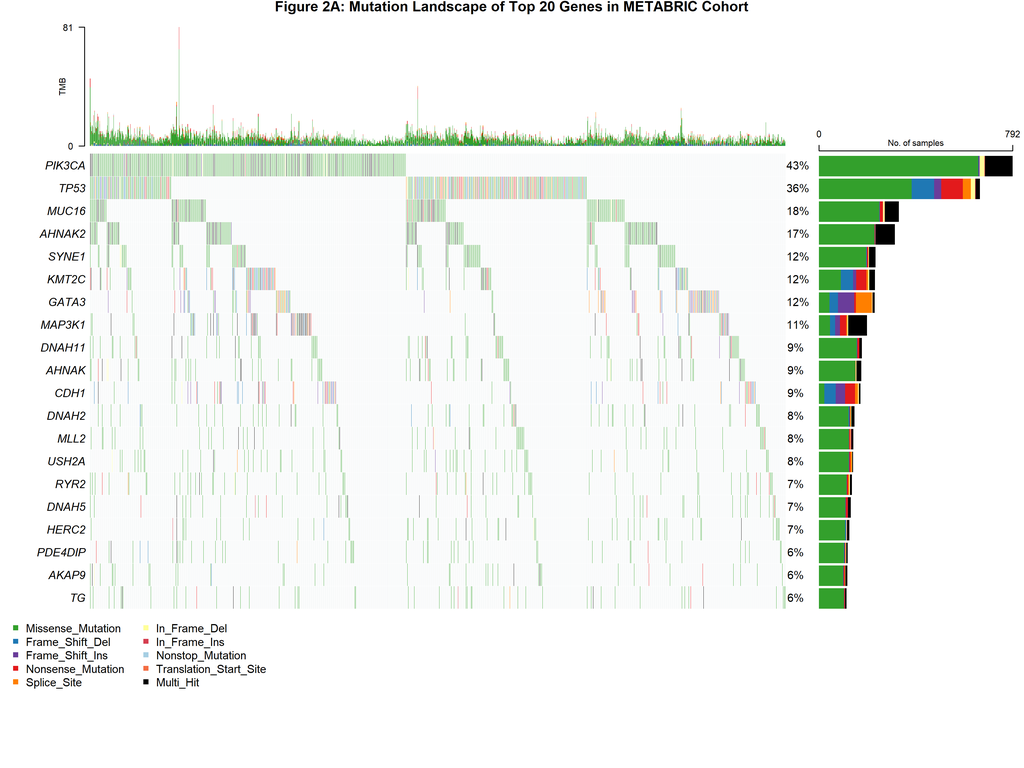

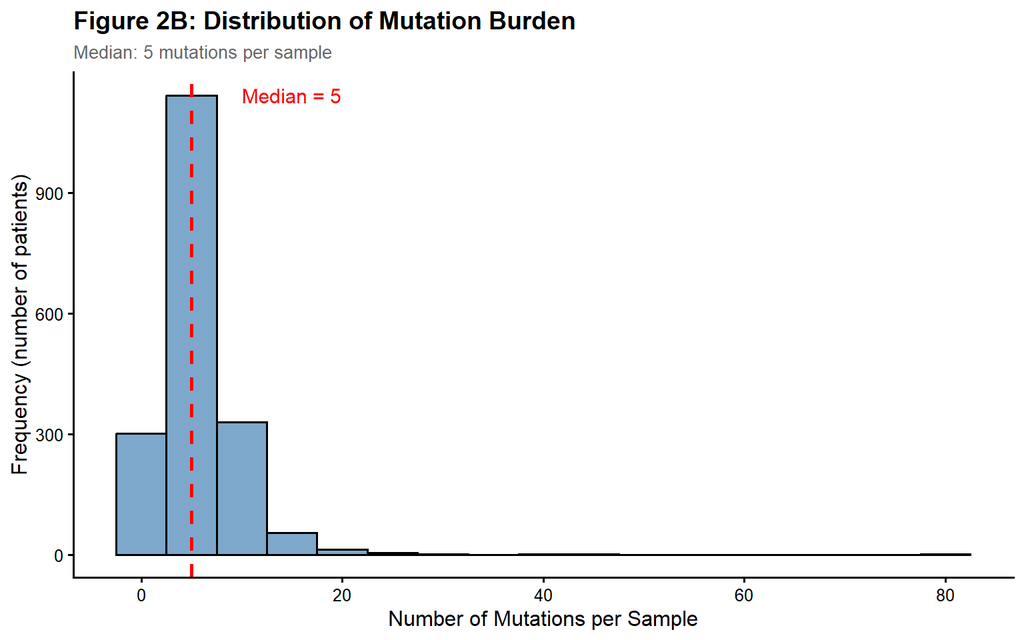

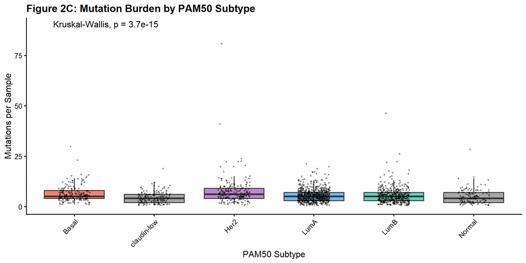

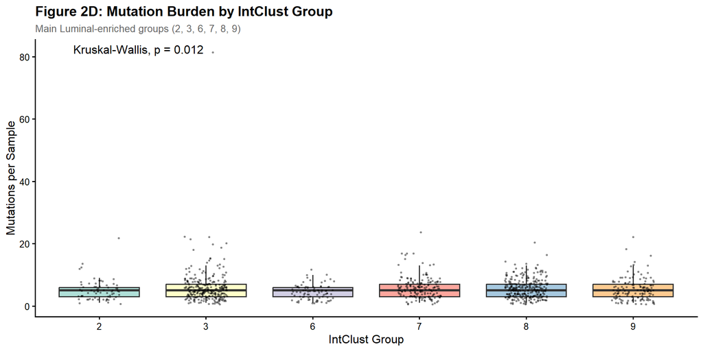

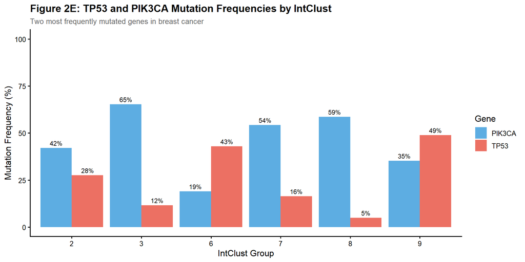

### Overall Mutation Landscape

The METABRIC cohort (n = 1860 patients with both mutation and clinical data) exhibited a median mutation burden of 5 mutations per sample (mean: 5.7, range: 1-81) (Figure 2B), with right skewing indicating most patients have low mutation burden and a small number of outliers with substantially higher counts (maximum: 81 mutations).

Among Luminal-enriched IntClust groups (2, 3, 6, 7, 8, 9), PIK3CA and TP53 were the most frequently mutated genes, though frequencies varied substantially across groups (Figure 2E). PIK3CA mutation frequency ranged from 19% (IC6) to 65% (IC3), while TP53 ranged from 5% (IC8) to 49% (IC9). These genes represent key oncogenic pathways: TP53 (tumour suppressor, genomic instability) and PIK3CA (PI3K pathway activation, cell survival). Notably, the high-risk groups IC6 and IC9 showed elevated TP53 mutations (43% and 49% respectively), consistent with their poorer prognosis.

### Mutation Burden and Subtype-Specific Patterns

Mutation burden differed significantly by PAM50 subtype (Kruskal-Wallis p = 3.7e-15, Figure 2C), with HER2-enriched tumours showing the highest median burden. Among Luminal-enriched IntClust groups, differences were less pronounced (Figure 2D), suggesting mutation burden alone does not fully explain IntClust-based risk stratification.

**TP53 Mutations:** TP53 mutation frequency differed significantly across IntClust groups (chi-square p = <2e-16) (Figure 2E). TP53 mutations were most frequent in IntClust 6 (43%) and IntClust 9 (49%), while low-risk groups showed substantially lower rates (IntClust 3: 12%, IntClust 8: 5%). This pattern reflects the association between TP53 loss and genomic instability in higher-risk subtypes.

**PIK3CA Mutations:** PIK3CA mutations showed significant patterns across IntClust groups (chi-square p = 8.37e-16), with higher frequency in low-risk Luminal groups, consistent with their association with ER-positive, less aggressive disease. PIK3CA mutations represent potential targets for PI3K inhibitors (André et al. 2019).

### Integration of Mutation and Copy Number Data

These mutation patterns complement the copy number-based IntClust classification. The fact that IntClust groups harbour distinct driver gene mutations (TP53 in high-risk groups, PIK3CA in low-risk groups) alongside their defining copy number profiles shows that different types of molecular data capture different aspects of tumour biology, which is why integrated multi-dimensional profiling adds value over any single data type.

## 3.4 Question 3: Clinical Integration

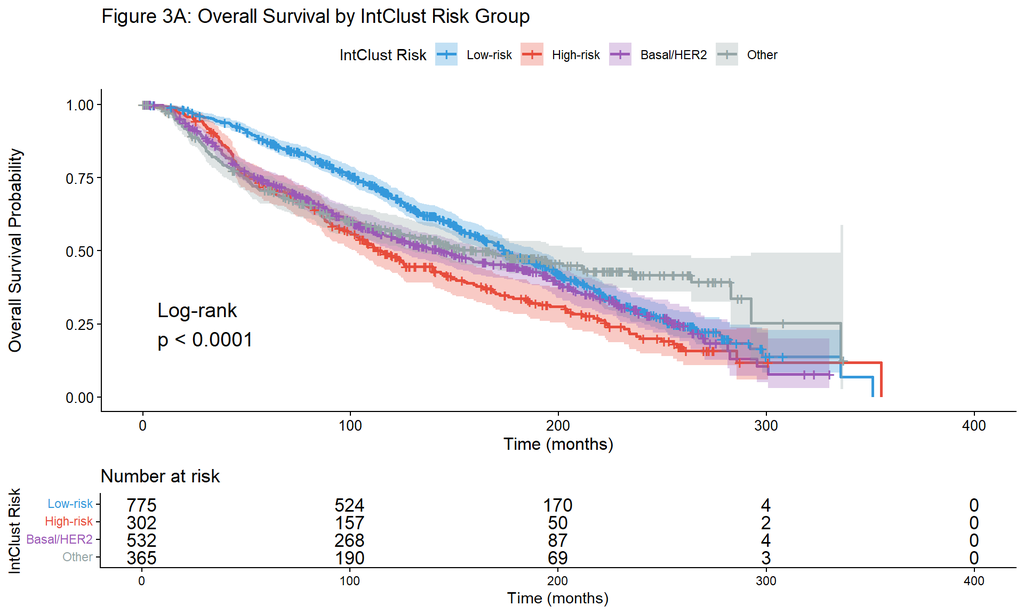

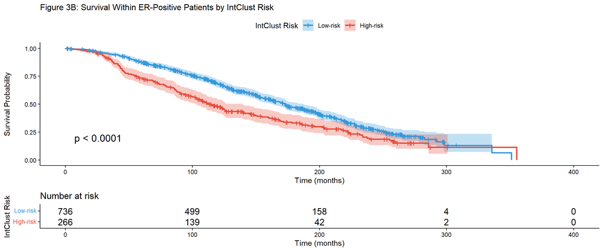

### IntClust Stratification Adds Prognostic Value

To assess whether IntClust classification provides prognostic information beyond standard clinical variables, we examined survival outcomes stratified by IntClust risk groups across the full cohort and within clinically defined subgroups.

**Overall Survival by IntClust Risk:** IntClust risk groups showed significantly different survival outcomes (log-rank p = 5.96e-06) (Figure 3A). Low-risk IntClust groups (3, 7, 8) demonstrated favorable survival, while high-risk groups (2, 6, 9) showed substantially worse outcomes. This validates IntClust’s prognostic utility at the population level.

**Stratification Within ER-Positive Patients:** Importantly, IntClust risk stratification remained significant even within ER-positive patients (log-rank p = 1.1e-06) (Figure 3B). Among the 1002 ER-positive patients analyzed, high-risk IntClust groups showed 68.8% mortality compared to 57.3% in low-risk groups, with a median survival difference of approximately 29 months.

This finding demonstrates that IntClust classification captures prognostic heterogeneity not explained by ER status alone. All ER-positive patients currently receive hormone therapy and broadly favorable prognostic messaging, yet IntClust identifies a substantial subset (18.6% of Luminal patients) with high-risk molecular profiles and worse outcomes. This represents a communication gap: patients classified as “Luminal” or “ER-positive” receive uniform prognostic information despite molecular heterogeneity that significantly affects survival.

### Robust vs. Uncertain Patterns

Robust findings include consistent IntClust survival differences across analyses, TP53 mutation association with poor prognosis, and specific genomic amplifications (CCND1, FGFR1) identifying high-risk subgroups within PAM50 Luminal classification. Less certain patterns include mutation burden differences (substantial overlap between groups), limited statistical power for smaller IntClust groups, and the optimal approach for communicating multi-dimensional genomic data to patients.

**Summary:** Molecular classification integrating copy number alterations (IntClust) stratifies patients beyond clinical variables and expression-based PAM50 classification. This means comprehensive genomic profiling captures risk information that current classification systems do not communicate to patients.

## 3.5 Extension: Hidden Heterogeneity in Luminal Patients

The gene expression analysis (Section 3.2) identified IntClust 2 and 6 as hidden high-risk groups defined by CCND1 and FGFR1 amplifications. For this extension, we additionally include **IntClust 9**, which the original METABRIC study identified as having poor survival driven by high genomic instability rather than a single amplification event (Curtis et al. 2012). While IntClust 9 lacks a single targetable amplification, its poor prognosis within PAM50 Luminal patients represents an additional hidden high-risk population receiving standard favourable messaging.

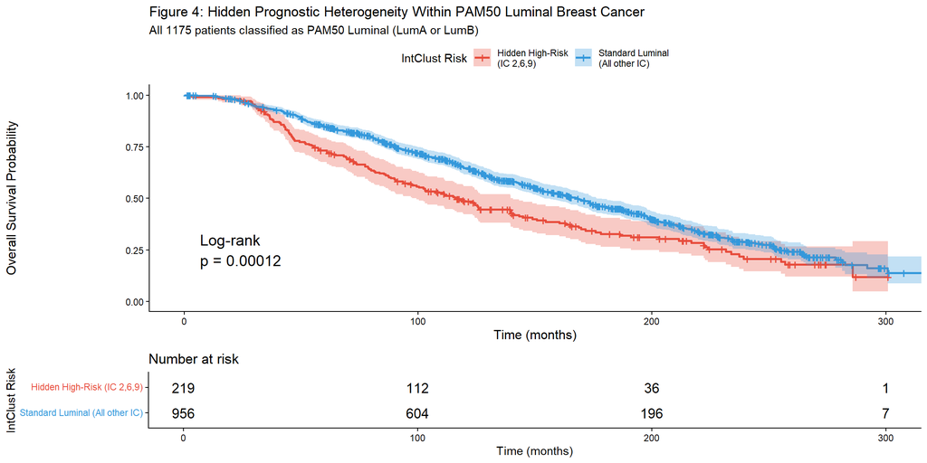

### Prevalence and Survival Impact

Of 1175 PAM50 Luminal patients, 219 (18.6%) belonged to high-risk IntClust groups: IntClust 2 (n = 60, 5.1%), IntClust 6 (n = 65, 5.5%), and IntClust 9 (n = 94, 8%). Figure 4 shows that these hidden high-risk patients had significantly worse overall survival compared to standard Luminal patients (log-rank p = 0.000124), with a mortality rate of 67.1% versus 57.1% and a median survival difference of approximately 23 months. This is a substantial gap given that all patients in both groups are classified as PAM50 Luminal and would typically receive similar prognostic messaging.